# Tarea-02

2023-08-22

## Solución

Podemos usar el suavizamiento loess para entender y describir el comportamiento de series de tiempo, en las cuales intentamos entender la dependencia de una serie de mediciones indexadas por el tiempo. Típicamente es necesario utilizar distintas *componentes* para describir exitosamente una serie de tiempo, y para esto usamos distintos tipos de suavizamientos. Veremos que distintas *componentes* varían en distintas escalas de tiempo (unas muy lentas, cono la tendencia, otras más rapidamente, como variación quincenal, etc.).

En el siguiente ejemplo consideramos la ventas semanales de un producto a lo largo de 5 años. Veamos que existe una tendencia a largo plazo (crecimientos anuales) y también que existen patrones de variación estacionales.

```r
library(tidyverse)
ventas <- read_csv("datos/ventas_semanal.csv")

# duda de transformación
ventas |>
  mutate(period_cat = cut_number(period, 5)) |>
  group_by(period_cat) |>
  summarise(sd_raw = round(sd(sales.kg), 1),
            sd_log = round(sd(log(sales.kg)), 2))
```

```
## # A tibble: 5 × 3
##   period_cat sd_raw sd_log
##   <fct>       <dbl>  <dbl>
## 1 [1,52.8]     106.   0.11
## 2 (52.8,105]   131.   0.11
## 3 (105,156]    138.   0.11
## 4 (156,208]    146.   0.11
## 5 (208,260]    145.   0.11
```

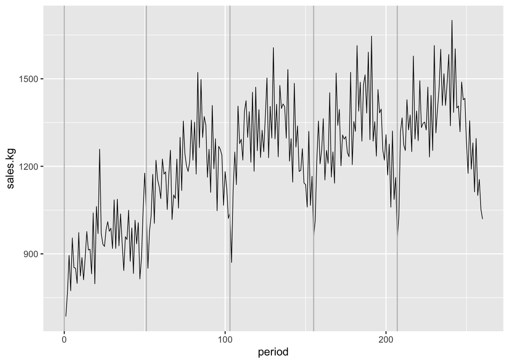

```r
ggplot(ventas, aes(x = period, y = sales.kg)) + geom_line(size = 0.3) +
    geom_vline(xintercept = c(0, 52 - 1, 52 * 2 - 1, 52 * 3 - 1, 52 * 4 - 1), color = "gray")
```

Intentaremos usar suavizamiento para capturar los distintos tipos de variación que observamos en la serie. En primer lugar, si suavizamos poco (por ejemplo $\aplha = 0.1$), vemos que capturamos en parte la tendencia y en parte la variación estacional.

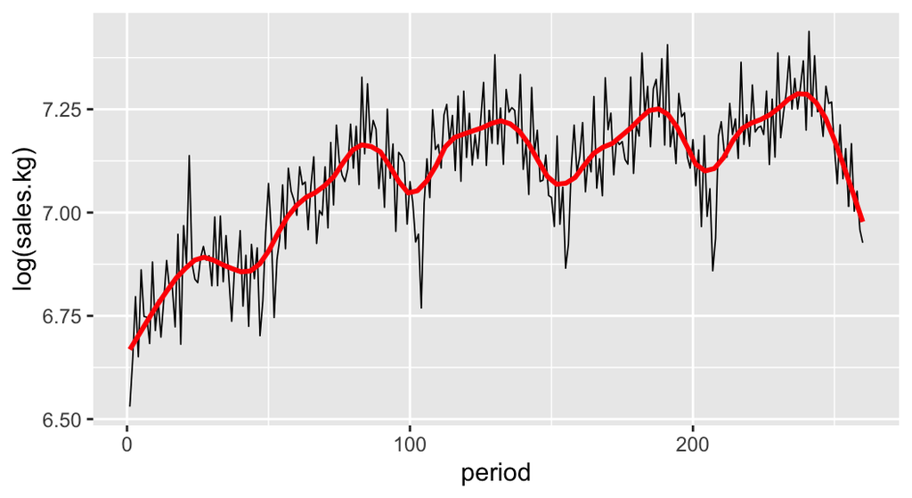

```r
ggplot(ventas, aes(x = period, y = log(sales.kg))) +
  geom_line(size = 0.3) +
  geom_smooth(method = "loess", span = 0.1, method.args = list(degree = 1),
              se = FALSE, size = 1,
    color = "red")
```

Es mejor comenzar capturando la tendencia, y poco de la componente estacional:

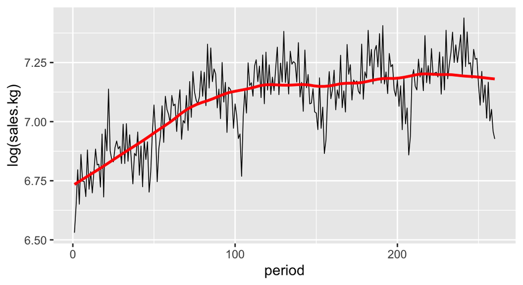

```r
ggplot(ventas, aes(x = period, y = log(sales.kg))) +
  geom_line(size = 0.3) +
  geom_smooth(method = "loess", span = 0.35, method.args = list(degree = 1),
              se = FALSE, size = 1,
    color = "red")
```

```r
ajuste_trend_1 <- loess(log(sales.kg) ~ period, ventas, span = 0.35,
                        degree = 1)
ventas <- ventas %>%
  add_column(trend_1 = ajuste_trend_1$fitted,
             res_trend_1 = ajuste_trend_1$residuals)
```

Ahora calculamos los residuales de este ajuste e intentamos describirlos mediante un suavizamiento más fino. Verificamos que hemos estimado la mayor parte de la tendencia, e intentamos capturar la variación estacional de los residuales.

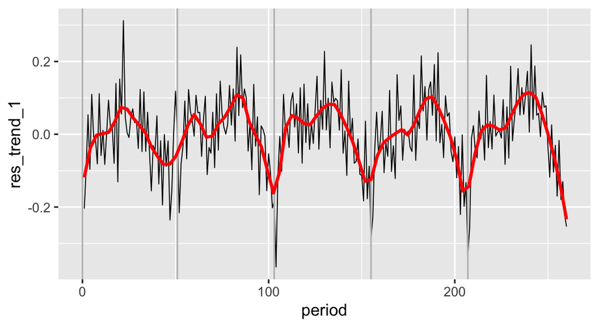

```r
ggplot(ventas, aes(x = period, y = res_trend_1)) +
  geom_line(size = 0.3) +
  geom_vline(xintercept = c(0, 52 - 1, 52 * 2 - 1, 52 * 3 - 1, 52 * 4 - 1),
             color = "gray") +
  geom_smooth(method = "loess", span = 0.08, method.args = list(degree = 2),
              se = FALSE, size = 1,
    color = "red")
```

```r
ajuste_est_1 <- loess(res_trend_1 ~ period, ventas, span = 0.08, degree = 2)
ventas <- ventas %>%
  add_column(est_1 = ajuste_est_1$fitted,
             res_est_1 = ajuste_est_1$residuals)
```

Y graficamos los residuales obtenidos después de ajustar el componente estacional.

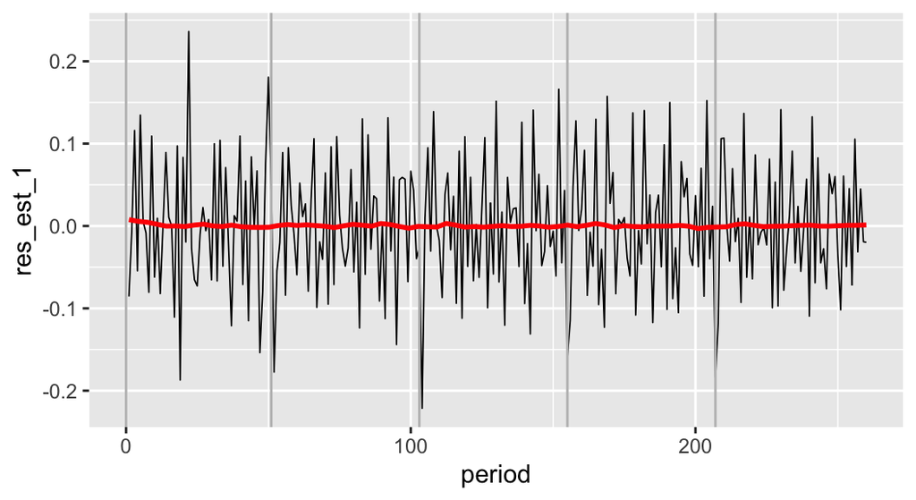

```r
ggplot(ventas, aes(x = period, y = res_est_1)) +
  geom_line(size = 0.3) +
  geom_vline(xintercept = c(0, 52 - 1, 52 * 2 - 1, 52 * 3 - 1, 52 * 4 - 1), color = "gray") +
  geom_smooth(method = "loess", span = 0.1, method.args = list(degree = 1),
              se = FALSE, size = 1,
    color = "red")
```

(opcional) Ahora que tenemos nuestra primera estimación de cada una de las componentes, podemos regresar a hacer una mejor estimación de la tendencia. La ventaja de volver es que ahora podemos suavizar más sin que en nuestra muestra compita tanto la variación estacional. Por tanto podemos suavizar menos:

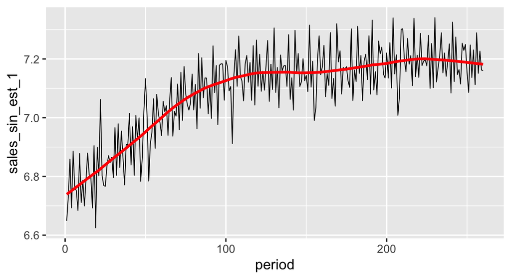

```r
ventas <- ventas %>%
  mutate(sales_sin_est_1 = log(sales.kg) - est_1)

ggplot(ventas, aes(x = period, y = sales_sin_est_1)) +
  geom_line(size = 0.3) +
  geom_smooth(method = "loess", span = 0.15, method.args = list(degree = 1),
              se = FALSE, size = 1,
    color = "red")
```

```r
ajuste_trend_2 <- loess(sales_sin_est_1 ~ period, ventas, span = 0.15, degree = 1)
ventas <- ventas %>%
  mutate(trend_2 = ajuste_trend_2$fitted,
         res_trend_2 = ajuste_trend_2$residuals,
         sales_sin_trend_2 = log(sales.kg) - trend_2)
```

Y ahora nos concentramos en la componente anual.

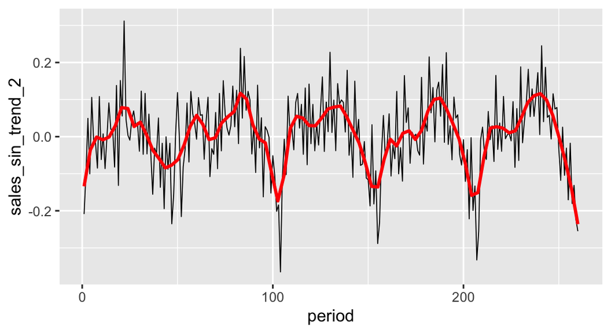

```r
ggplot(ventas, aes(x = period, y = sales_sin_trend_2)) +
  geom_line(size = 0.3) +
  geom_smooth(method = "loess", span = 0.07, se = FALSE, size = 1,
              method.args = list(degree = 2),
              color = "red")
```

```r
ajuste_est_2 <- loess(sales_sin_trend_2 ~ period, ventas, span = 0.07, degree = 1)
ventas <- ventas %>%
  mutate(est_2 = ajuste_est_2$fitted,
         res_est_2 = ajuste_est_2$residuals)
```

Visualizamos el ajuste:

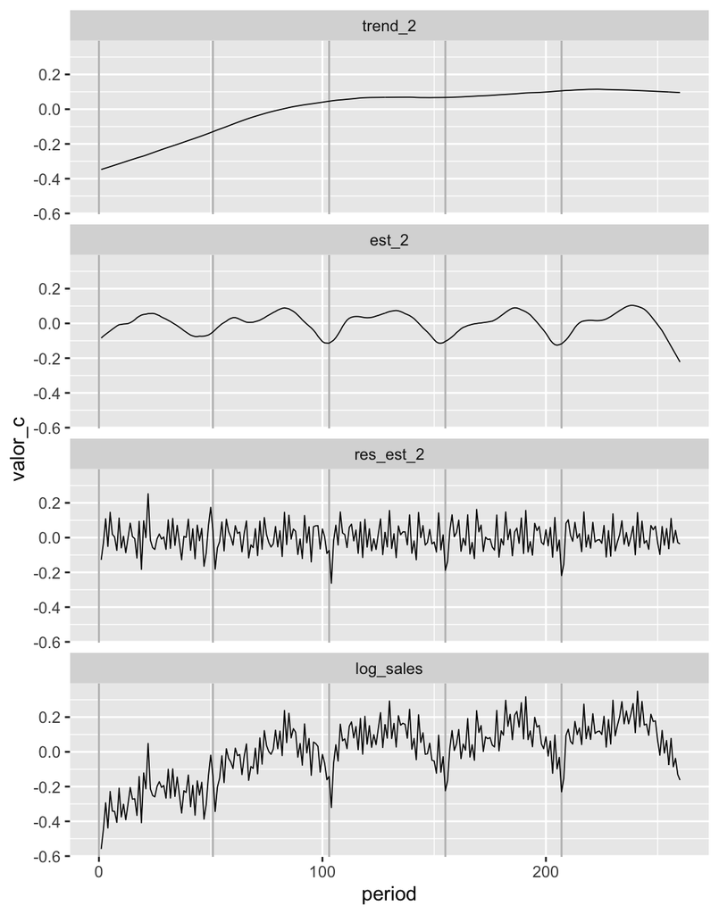

```r
ventas$log_sales <- log(ventas$sales.kg)
ventas_2 <- dplyr::select(ventas, period, trend_2, est_2, res_est_2,
  log_sales)

ventas_2_m <- pivot_longer(ventas_2, -period, names_to = "componente",
                           values_to = "valor")

ventas_2_m_c <- ventas_2_m %>%
  group_by(componente) %>%
  mutate(
    valor_c = valor - mean(valor),
    componente = factor(componente, c("trend_2", "est_2", "res_est_2", "log_sales"))
  )

ggplot(ventas_2_m_c, aes(x = period, y = valor_c)) +
  geom_vline(xintercept = c(0, 52 - 1, 52 * 2 - 1, 52 * 3 - 1, 52 * 4 - 1), color = "gray") +
  geom_line(size = 0.3) +
  facet_wrap(~ componente, ncol = 1)
```

**Adicional** Y analizamos si es razonable describir los residuales con una distribución normal (con desviación estándar alrededor de 8% sobre el valor ajustado):

```r
sd(ventas$res_est_2)
```

```
## [1] 0.08228131
```

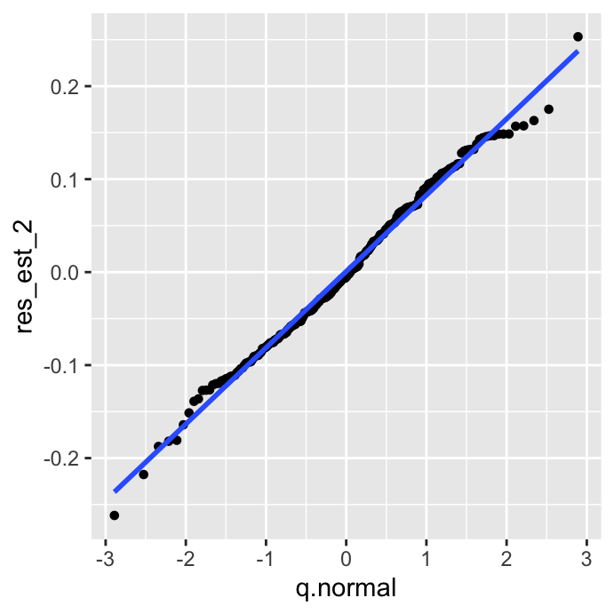

```r
ventas_ord <- arrange(ventas, res_est_2)
ventas_ord$q.normal <- qnorm((1:nrow(ventas) - 0.5) / nrow(ventas))
ggplot(ventas_ord, aes(x = q.normal, y = res_est_2)) +
  geom_point(size = 1.2) +
  geom_smooth(method = "lm")
```

Aún no estamos convencidos de que podemos hacer *pooling* de los residuales. Para checar esto, vemos la gráfica de dependencia de residuales.

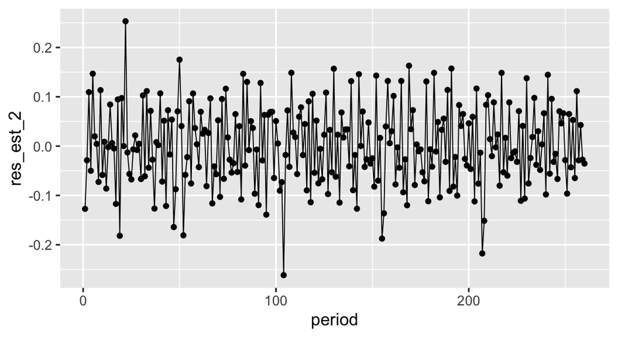

```r
ggplot(ventas, aes(x = period, y = res_est_2)) + geom_line(size = 0.3) +
  geom_point(size = 1.2)
```

¿Puedes notar alguna dependencia en los residuales?

```r
library(nullabor)
ventas_res <- dplyr::select(ventas, period, res_est_2)
ventas_null <- lineup(null_dist(var = 'res_est_2', dist = 'normal',
  params = list(mean = 0, sd = 0.08)), n = 10, ventas_res)
```

```
## decrypt("clZx bKhK oL 3OHohoOL BE")
```

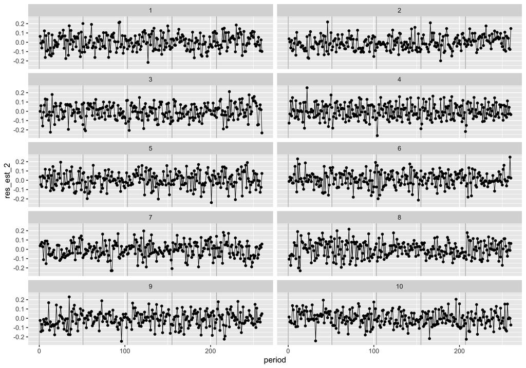

```r
ggplot(ventas_null, aes(x = period, y = res_est_2)) +
  facet_wrap(~ .sample, ncol = 2) +
  geom_line(size = 0.3) +
  geom_vline(xintercept = c(0, 52 - 1, 52 * 2 - 1, 52 * 3 - 1, 52 * 4 - 1), color = "gray") +
  geom_point(size = 1.2)
```

Hay dos cosas que nos falta explicar, en primer lugar, las caídas alrededor de principios/finales de cada año (que son de hasta -0.2), y segundo que esta gráfica parece oscilar demasiado. La estructura que aún no hemos explicado se debe a que las semanas que caen en quincena tienden a tener compras más grandes que las que están justo antes de quincena o fin de mes.

Por el momento detendremos el análisis aquí.